# BL40A2010 Introduction to IoT-Based Systems

## Assignment 5, 20.09.2022

### Author: Trieu Huynh Ba Nguyen

**(1) Create two arrays with 10000 samples generated as [Binomial](https://en.wikipedia.org/wiki/Binomial_distribution) random variables via [Numpy](https://docs.scipy.org/doc/numpy/reference/generated/numpy.random.binomial.html) similar to what we have done with Poisson random variables in the tutorial considering the following paramenters of the Binomial function:**

**(a) $n=100$ and $p=0.3$;**

**(b) $n=10000$, and $p=0.6$**

**Make the histogram (empirical) plots related to each vector and compare them with the analytical results with the probability distribution funtion given by:**

**$$\mathrm{Prob}\left[X = k \right] = \binom{n}{k}p^k(1-p)^{n-k},$$ where $k$ is the number of *successes* in $n$ trials.**

**Remember to use this [scipy.stats.binom](https://docs.scipy.org/doc/scipy-0.14.0/reference/generated/scipy.stats.binom.html) in a similar way we did in the tutorial with Poisson.**

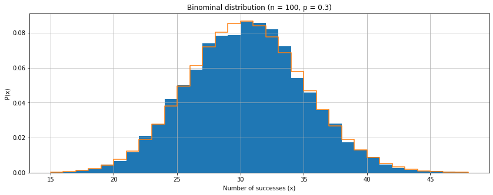

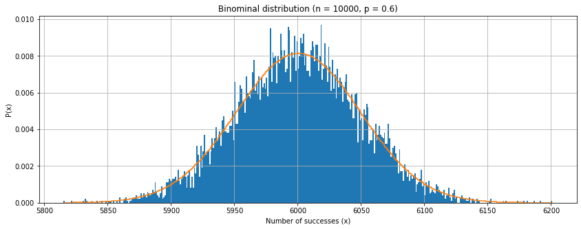

```python
import numpy as np
from scipy.stats import binom
import matplotlib.pyplot as plt

x = np.random.binomial(100, 0.3, 10000)
n1 = np.arange(np.min(x),np.max(x)+1, 1)
bins_x = np.max(x) - np.min(x)
plt.figure(figsize=(14,5))
plt.hist(x,bins_x,density=True)
plt.step(n1,binom.pmf(n1,100, 0.3), where='post')
plt.title('Binominal distribution (n = 100, p = 0.3)')
plt.xlabel('Number of successes (x)')
plt.ylabel('P(x)')
plt.grid(True)
plt.show()

y = np.random.binomial(10000, 0.6, 10000)
n2 = np.arange(np.min(y),np.max(y)+1, 1)
bins_y = np.max(y) - np.min(y)
plt.figure(figsize=(14,5))
plt.hist(y,bins_y,density=True)
plt.step(n2,binom.pmf(n2,10000, 0.6), where='post')
plt.title('Binominal distribution (n = 10000, p = 0.6)')
plt.xlabel('Number of successes (x)')
plt.ylabel('P(x)')
plt.grid(True)
plt.show()
```

**(2) Read Section 2.3 and Chapter 3 from [Network Science](http://networksciencebook.com/) and generate three different kinds of Erdos-Renyi graphs with $N=15$ (fifteen nodes) using [NetworkX](https://networkx.github.io/documentation/stable/reference/generated/networkx.generators.random_graphs.erdos_renyi_graph.html?highlight=erdos#networkx.generators.random_graphs.erdos_renyi_graph). The networks shall be (a) with probability $p=0.2$, (b) with probability $p=0.5$ and (c) with probability $p=0.8$. Discuss about the differences you see if these graphs represent communication networks.**

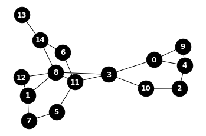

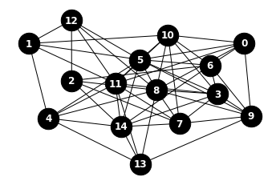

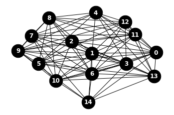

```python
import networkx as nx

G1 = nx.erdos_renyi_graph(15,0.2)
nx.draw_networkx(G1, node_color='black', font_color='white', edge_color='black', font_weight='bold',  node_size=700)
plt.axis('off')
plt.show()

G2 = nx.erdos_renyi_graph(15,0.5)
nx.draw_networkx(G2, node_color='black', font_color='white', edge_color='black', font_weight='bold',  node_size=700)
plt.axis('off')
plt.show()

G3 = nx.erdos_renyi_graph(15,0.8)
nx.draw_networkx(G3, node_color='black', font_color='white', edge_color='black', font_weight='bold',  node_size=700)
plt.axis('off')
plt.show()
```